# Process Unispec Files collected on One Day

Ruby An

2021-07-29

## Introduction

This file is fo processing unispec data in a user friendly way.

## Required Packages & Functions

## Read in data

- data_path is year folder where the session files are stored. The structure is year/spu/yyyy-mm-dd where yyyy-mm-dd is sample date. Should be on OneDrive.
- Field Key file with header “Date,Site,Block,Treatment,Replicate,Location,FileNum,Notes,Weather”. File name convention is year_unispec_field_key.csv

### Read .SPU files

### Read Unispec File Key

### QAQC: Unispec Key & .spu file Correspondance

```
## [1] "Total number of .spu files: 685"
```

```
## [1] "Total number of scans documented: 685"
```

```
## [1] "QUALITY CHECKS: all answers should be zero if things ran well"
```

```
## [1] "Missing .spu files: 0"
```

```
## [1] "Scan Locations missing info: 20"
```

```
## [1] "Plots with an abnormal number of scans (not a clean multiple of 5): 0"
```

## Correct data with REFerence files

White references correct for instrument & cable irregularities. Multiplying by the correction factor (ChA/ChB) smooths out the spectra. There are typically 5 reference measurements per *Date* / *Site*. If multiple file numbers are listed, the correction factors are averaged.

Based on the original field notebook key and the following quality checks, choose reference files by entering the appropriate file numbers in the field keys for the rows where the column *Treatment* = **REF**.

Make sure to rerun the **Read Unispec Keys** if you change REF file choices. The following code plots your chosen references for a visual check.

### Choose & Check References

```
## # A tibble: 5 x 5
## # Groups:   Date, Site [4]
##   Date       Site  Integration Files ref_filenames
##   <date>     <fct>       <dbl> <int> <chr>
## 1 2020-07-19 DHT89          60     9 dht89_00002.spu, dht89_00002.spu, dht89_00…
## 2 2020-07-19 MNN97          50    14 mnn97_00002.spu, mnn97_00002.spu, mnn97_00…
## 3 2020-07-19 MNT97          50    15 mnt97_00001.spu, mnt97_00001.spu, mnt97_00…
## 4 2020-07-19 WSG89          50     9 wsg89_00002.spu, wsg89_00002.spu, wsg89_00…
## 5 2020-07-19 WSG89          55    14 wsg89_01002.spu, wsg89_01002.spu, wsg89_01…
```

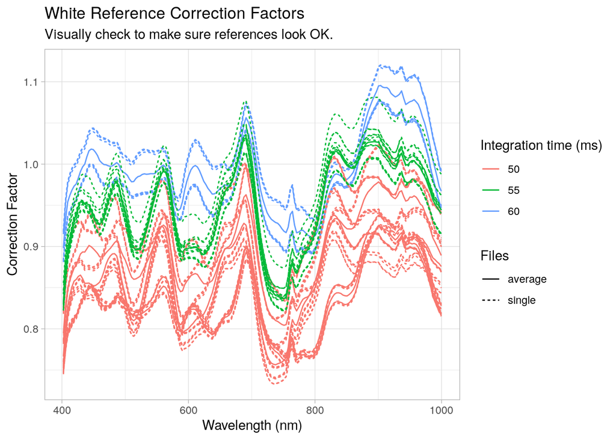

### Apply References

Rerun the **Join Data & keys** sections above to update the `raw_data` dataframe. Apply your chosen references to actual spectral data to create the tidy dataframe `processed_data` containing corrected sepectral reflectance values.

INPUTS: - raw_data - correction_factors

OUTPUT: - processed_data - plot of first 30 files to check

### QAQC application

```
## [1] "Number of raw files: 685"
```

```
## [1] "Number of corrected Files: 685"
```

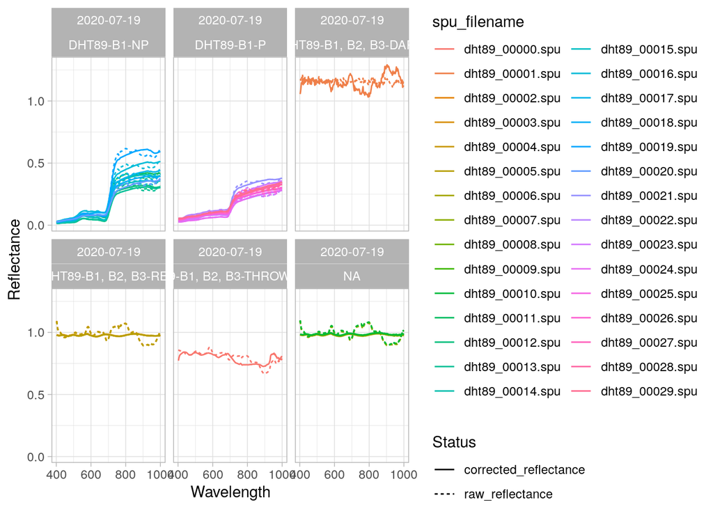

## Calculate INDICES

Currently, this only works for NDVI, EVI, and EVI2 as I haven’t worked out spectral interpolation yet and the other indices need reflectance at a specific value (not a range).

### Calculate Indices

### QAQC: Visualize with other years

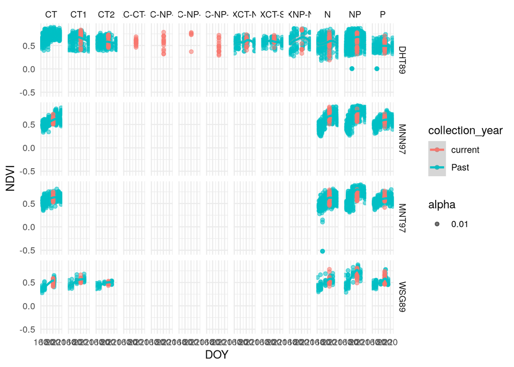

## SAVE DATA

## CHECKLIST/SUMMARY REPORT